# Impact of Experience and Payment Tier on Employee Retention

## Question 1: How strongly do Payment Tier and Experience in Current Domain correlate with the likelihood of an employee leaving (Leave or Not)?

Analysis:

Calculate correlations between variables.

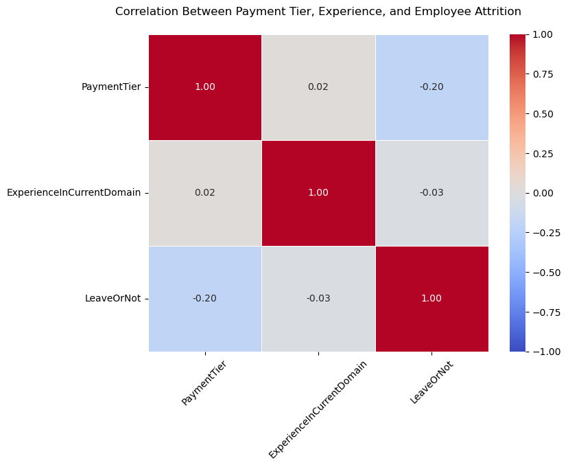

```python
import pandas as pd
import matplotlib.pyplot as plt
import seaborn as sns

# Load dataset
df = pd.read_csv("Employee.csv")

# Calculate correlations
corr_matrix = df[['PaymentTier', 'ExperienceInCurrentDomain', 'LeaveOrNot']].corr()

# Create heatmap
plt.figure(figsize=(8, 6))
sns.heatmap(
    corr_matrix,
    annot=True,
    cmap='coolwarm',
    vmin=-1,
    vmax=1,
    linewidths=0.5,
    fmt=".2f"
)
plt.title("Correlation Between Payment Tier, Experience, and Employee Attrition", pad=20)
plt.xticks(rotation=45)
plt.yticks(rotation=0)
plt.savefig('correlation_btw_payment_tier_experience_and_employee_attrition.png')
plt.show()
```

Interpretation:

Payment Tier vs. Attrition (LeaveOrNot)

Experience vs. Attrition

Correlation coefficient: -0.03 (negligible correlation).

Experience in the current domain has almost no impact on retention.

Payment Tier vs. Experience

## Question 2: Do employees in higher Payment Tiers (e.g., Tier 1 vs. Tier 3) exhibit significantly lower attrition rates?

Analysis:

Compared attrition rates across Payment Tiers.

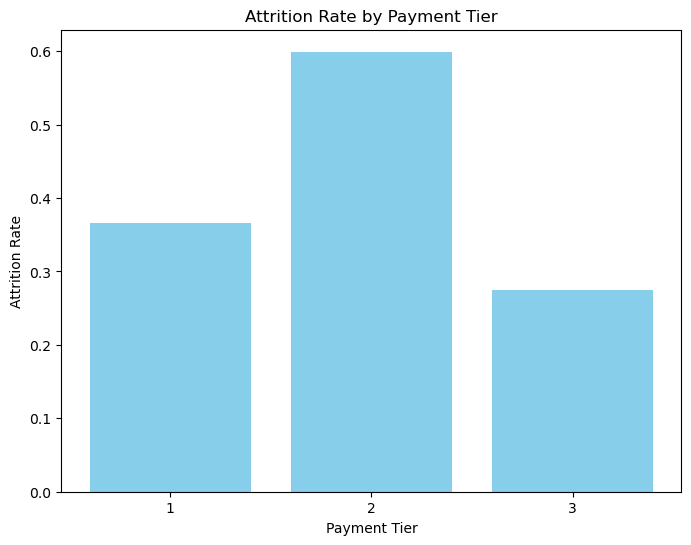

```python
# Attrition rate by Payment Tier
attrition_rate = df.groupby('PaymentTier')['LeaveOrNot'].mean().reset_index()

# Bar chart
plt.figure(figsize=(8, 6))
plt.bar(attrition_rate['PaymentTier'], attrition_rate['LeaveOrNot'], color='skyblue')
plt.xlabel('Payment Tier')
plt.ylabel('Attrition Rate')
plt.title('Attrition Rate by Payment Tier')
plt.xticks([1, 2, 3])
plt.savefig('attrition_rate_by_payment_tier.png')
plt.show()
```

Insight:

## Question 3: Is there a critical threshold of Experience in Current Domain (e.g., 2+ years) beyond which retention rates improve markedly?

Analysis: Group experience into bins and calculate attrition rates.

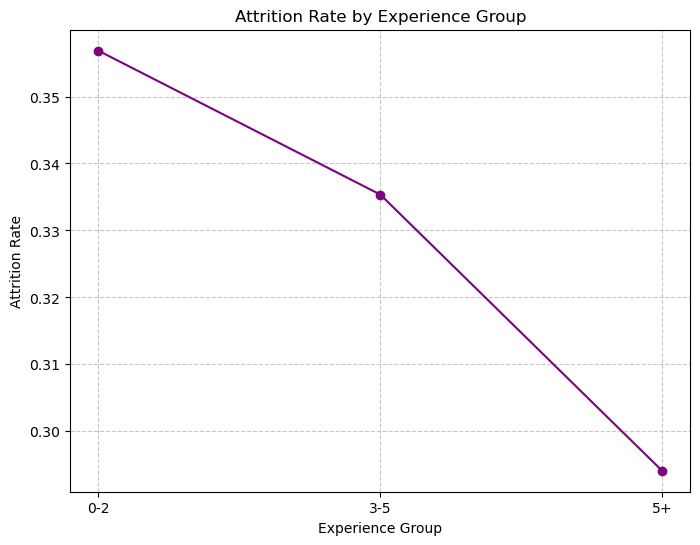

```python
# Bin experience into groups
df['ExperienceGroup'] = pd.cut(
    df['ExperienceInCurrentDomain'],
    bins=[0, 2, 5, 10],
    labels=['0-2', '3-5', '5+']
)

# Attrition by experience group (with observed=False)
attrition_exp = df.groupby('ExperienceGroup', observed=False)['LeaveOrNot'].mean().reset_index()

# Line chart
plt.figure(figsize=(8, 6))
plt.plot(attrition_exp['ExperienceGroup'], attrition_exp['LeaveOrNot'], marker='o', color='purple')
plt.xlabel('Experience Group')
plt.ylabel('Attrition Rate')
plt.title('Attrition Rate by Experience Group')
plt.grid(True, linestyle='--', alpha=0.7)
plt.savefig('attrition_rate_by_experience_group.png')
plt.show()
```

Insight:

## Question 4: Does the combination of low Payment Tier and high Experience in Current Domain lead to disproportionately higher attrition rates?

Analysis: Compared attrition rates for combinations of Payment Tier and Experience.

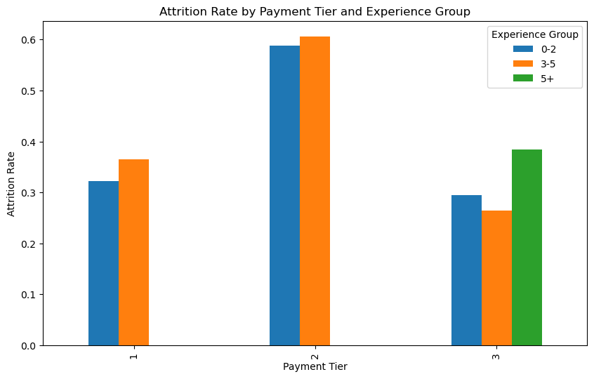

```python
# Pivot table with observed=False to suppress the warning
pivot = df.pivot_table(
    index='PaymentTier',
    columns='ExperienceGroup',
    values='LeaveOrNot',
    aggfunc='mean',
    observed=False  # <-- Add this parameter
)

# Grouped bar chart
pivot.plot(kind='bar', figsize=(10, 6))
plt.xlabel('Payment Tier')
plt.ylabel('Attrition Rate')
plt.title('Attrition Rate by Payment Tier and Experience Group')
plt.legend(title='Experience Group')
plt.savefig('attrition_rate_by_payment_tier_and_experience_group.png')
plt.show()
```

Insight:

## Question 5: How does being benched (Ever Benched) interact with Payment Tier and Experience to influence retention decisions?

Analysis: Compared attrition rates for benched vs. non-benched employees.

[figure not shown]

```python
# Stacked bar chart: Benched vs. Payment Tier
bench_pivot = df.pivot_table(index='EverBenched',
                             columns='PaymentTier',
                             values='LeaveOrNot',
                             aggfunc='mean')

bench_pivot.T.plot(kind='bar', stacked=True, figsize=(10, 6))
plt.xlabel('Payment Tier')
plt.ylabel('Attrition Rate')
plt.title('Attrition Rate by Payment Tier and Bench Status')
plt.legend(title='Benched?')
plt.savefig('attrition_rate_by_payment_tier_and_bench_status.png')
plt.show()
```

## Question 6: Are retention patterns linked to Payment Tier and Experience consistent across genders or age groups?

Analysis: Compare attrition rates by gender and Payment Tier.

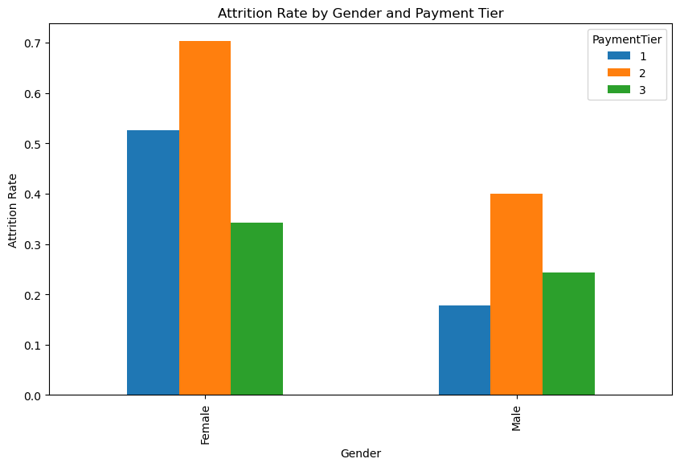

```python
# Grouped bar chart: Gender vs. Payment Tier
gender_pivot = df.pivot_table(index='Gender',
                              columns='PaymentTier',
                              values='LeaveOrNot',
                              aggfunc='mean')

gender_pivot.plot(kind='bar', figsize=(10, 6))
plt.xlabel('Gender')
plt.ylabel('Attrition Rate')
plt.title('Attrition Rate by Gender and Payment Tier')
plt.savefig('attrition_rate_by_gender_and_payment_tier.png')
plt.show()
```

Insight:

## Question 7: Do geographic locations (e.g., Bangalore vs. Pune) show distinct retention behaviors when comparing Payment Tier and Experience levels?

Analysis: Compare attrition rates across cities.

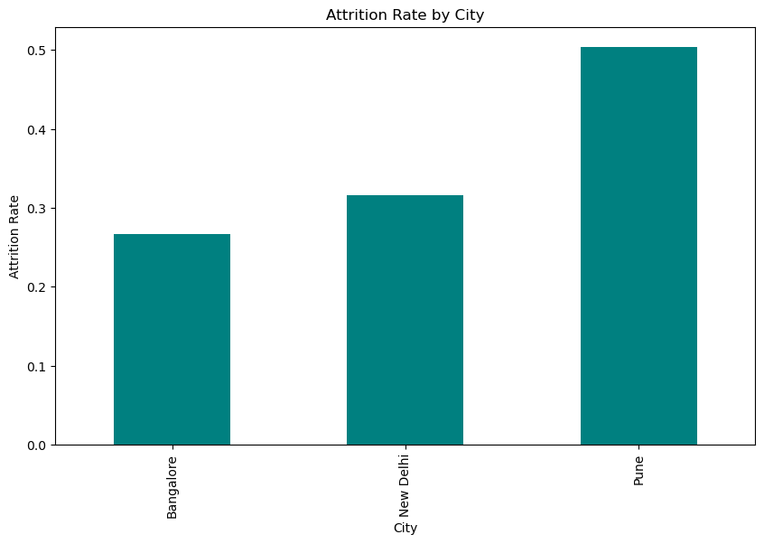

```python
# Bar chart by City
city_attrition = df.groupby('City')['LeaveOrNot'].mean().sort_values()

plt.figure(figsize=(10, 6))
city_attrition.plot(kind='bar', color='teal')
plt.xlabel('City')
plt.ylabel('Attrition Rate')
plt.title('Attrition Rate by City')
plt.savefig('attrition_rate_by_city.png')
plt.show()
```

Insight:

## Question 8: Does educational attainment (e.g., Bachelors vs. Masters) moderate the relationship between Payment Tier, Experience, and retention?

Analysis: Compared attrition rates by education level.

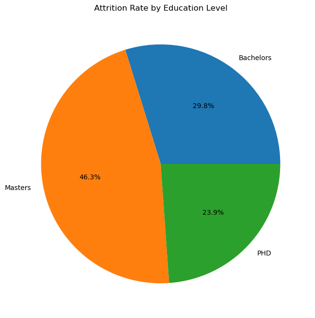

```python
# Pie chart: Attrition by Education
education_attrition = df.groupby('Education')['LeaveOrNot'].mean()

plt.figure(figsize=(8, 8))
education_attrition.plot(kind='pie', autopct='%1.1f%%')
plt.ylabel('')
plt.title('Attrition Rate by Education Level')
plt.savefig('attrition_rate_by_education_level.png')
plt.show()
```

Insight:

## Question 9: How does Joining Year (e.g., employees hired in 2012 vs. 2018) interact with Payment Tier and Experience to predict retention?

Analysis: Track attrition trends over time.

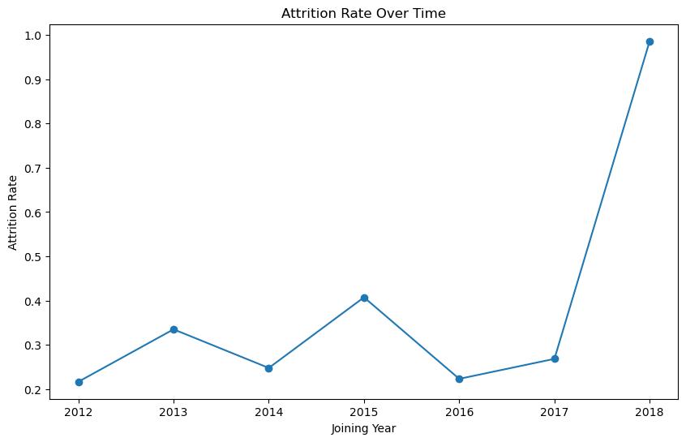

```python
# Line chart: Attrition by Joining Year
year_attrition = df.groupby('JoiningYear')['LeaveOrNot'].mean()

plt.figure(figsize=(10, 6))
year_attrition.plot(kind='line', marker='o')
plt.xlabel('Joining Year')
plt.ylabel('Attrition Rate')
plt.title('Attrition Rate Over Time')
plt.savefig('attrition_rate_over_time.png')
plt.show()
```

Insight:

## Question 10: Are employees with high Experience in Current Domain but low Payment Tiers more likely to leave, suggesting perceived inequity?

Analysis: Compared attrition for high-experience employees in low tiers.

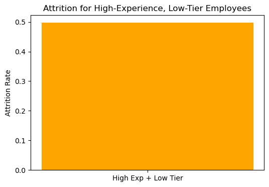

```python
# Filter high experience (5+ years) and low tier (1-2)
high_exp_low_tier = df[(df['ExperienceInCurrentDomain'] >= 5) & (df['PaymentTier'] <= 2)]
attrition_rate = high_exp_low_tier['LeaveOrNot'].mean()

# Bar chart
plt.figure(figsize=(6, 4))
plt.bar(['High Exp + Low Tier'], [attrition_rate], color='orange')
plt.ylabel('Attrition Rate')
plt.title('Attrition for High-Experience, Low-Tier Employees')
plt.savefig('attrition_for_high-experience_low-tier_employees.png')
plt.show()
```